# Monte Carlo vs Monte Carlo con Bootstrap

para intervalos de Confianza y otras estadisticas de r_t

Diego

2024-12-01

Al trabajar con datos reales, ya no conoceremos los valores verdaderos de $\theta$ bajo el modelo. Por ello nos detuvimos tanto en la parte de estimacion de parametros, para asegurar que habiamos llegado a un algoritmo de Simulated Annealing confiable

El esquema con el que vamos a abordar el problema sera:

1. ```
   Importar el conjunto de datos con el que trabajaremos en el modelo de Vasicek
   ```

2. ```
   Estimar los parametros
   ```

3. ```
   Simular m trayectorias del modelo *(con los parametros estimados)*
   ```

4. ```
   Compararlas visualmente con la trayectoria real observada de los datos, buscando alguna señal de que el ajuste no fue bueno.
   ```

5. ```
   Mediante **Bootstrap** haremos inferencia sobre el modelo ya ajustado
   ```

6. ```
   Usar lo anterior para predecir el comportamiento futuro de los datos asi como para valuar bonos u otros activos financieros que dependan de tasas de interes
   ```

## Bootstrap para re-muestrear trayectorias

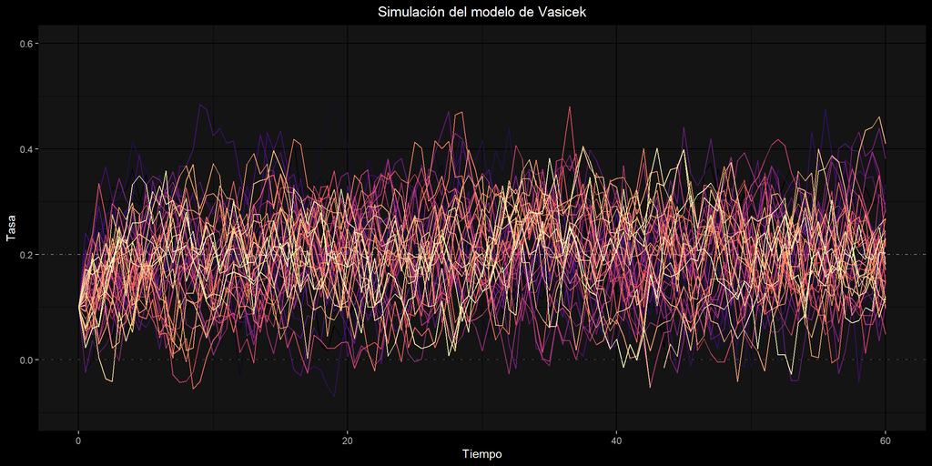

Calculamos para cada tiempo t en el que hay datos:

- intervalos de confianza
- mediana
- media

Primero muestralmente y luego utilizando remuestro Bootstrap con 200 muestras bootstrap y que el tamaño de cada una sea del doble de la muestra original, es decir 2m trayectorias

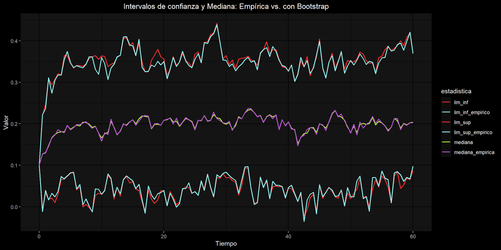

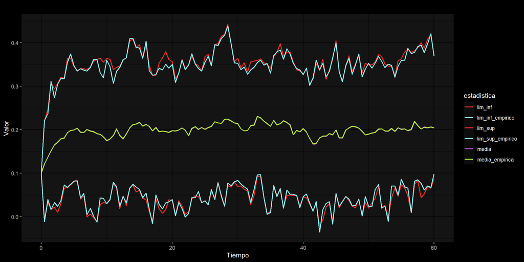

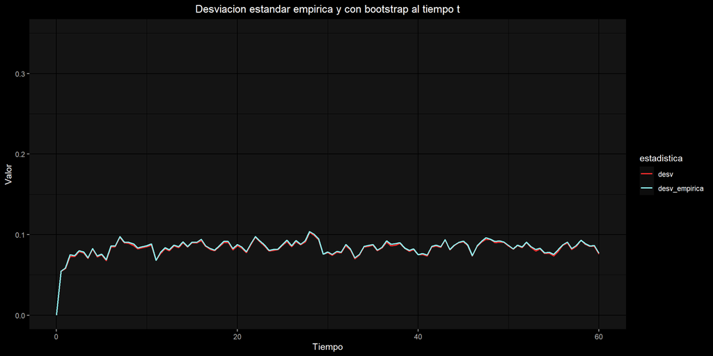

Originalmente lo habiamos hecho para 500 muestras bootstrap, luego lo bajamos a 200 pero aun asi, el costo computacional no vale la pena, ya que como se puede notar en las grficas anteriores, los intervalos de confianza, medias, medianas y desviaciones estandar remuestreando con bootstrap son casi iguales a las que se obtienen calculandolas directamente de las trayectorias simuladas, pero el tiempo de ejecicion se incrementa bastante.

Probamos con otros valores, aumentando todos los parametros y el numero de observaciones a ver si notamos una diferencia sustancial entre usar Bootstrap y no usarlo:

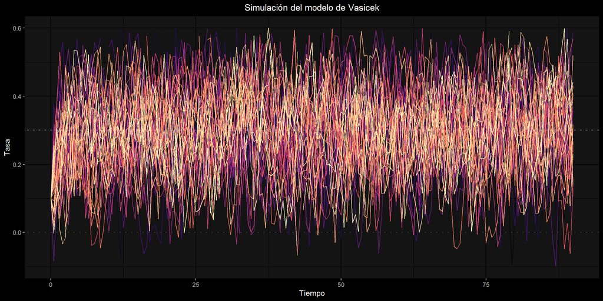

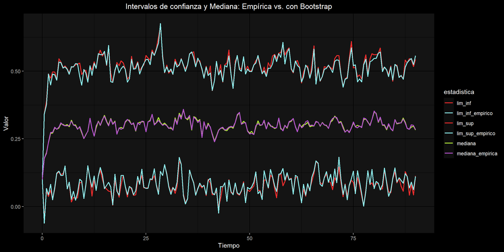

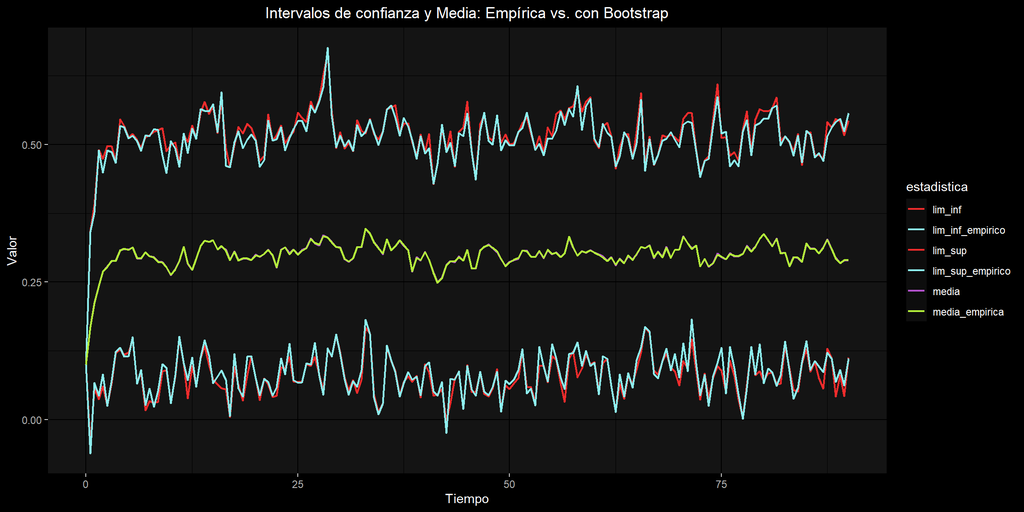

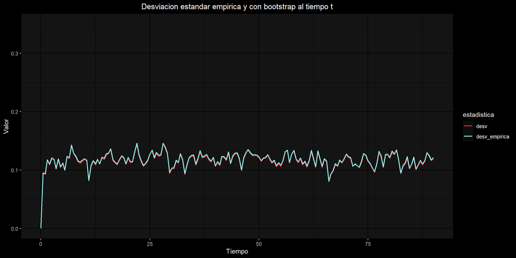

Una vez mas, los calculos son casi los mismos. Se puede probar con mas combinaciones de valores hasta convencerse a uno mismo de que no vale el costo computacional, por lo que en lo sucesivo se trabajara sin Bootstrap, directamente de la muestra.

Terminaremos esta seccion elaborando una funcion que, cuando introduzcamos una simulacion de m trayectorias, elabore intervalos de confianza, mediana, media y desviacion estandar muestrales, asi como el valor esperado en cada punto del tiempo de acuerdo al modelo de Vasicek

Probemos para estas 60 trayectorias con $t_f = 60$, $dt=0.5$, $r_0=0.1$, $\theta = (0.5,0.2,0.08)$

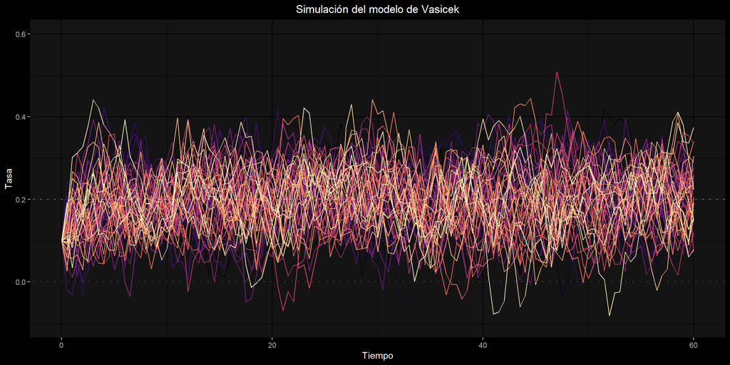

Su intervalo de confianza, media y mediana se ven:

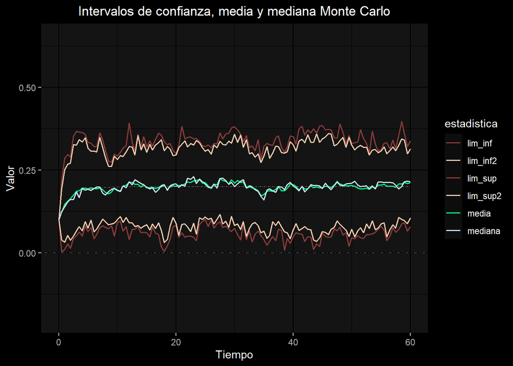